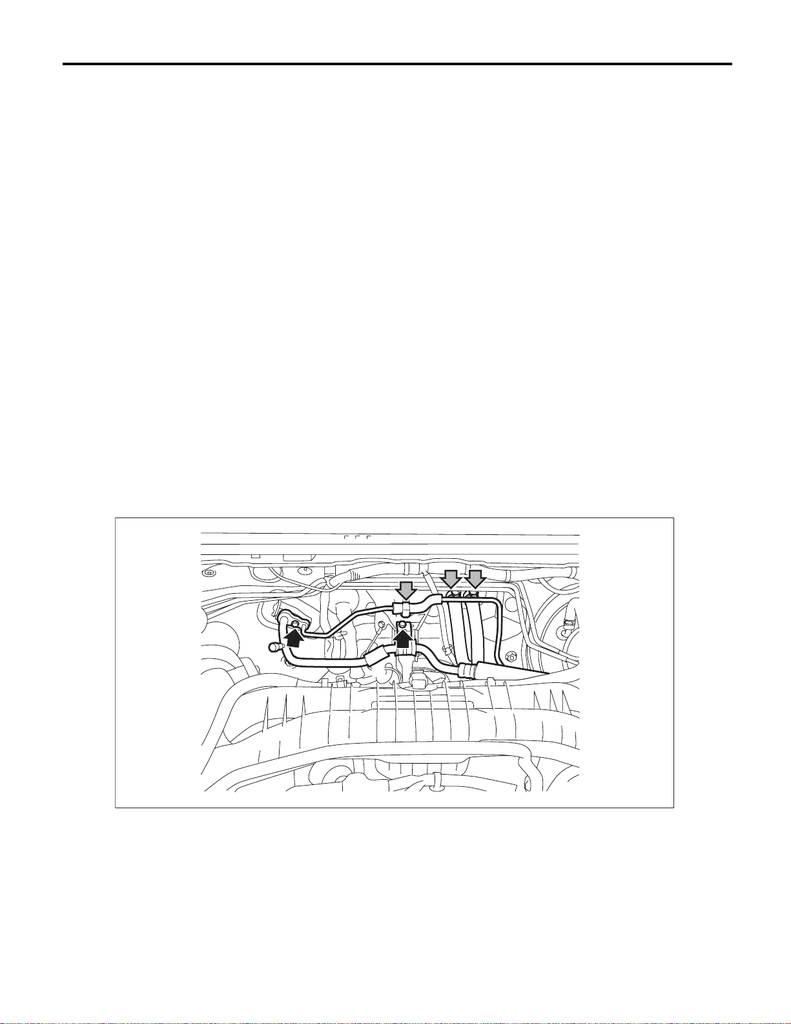

AC-54

Heater and Cooling Unit

HVAC SYSTEM (HEATER, VENTILATOR AND A/C)

16.Heater and Cooling Unit

A: REMOVAL

CAUTION:

Before handling the airbag module, refer to “CAUTION” of “General Description” in “AIRBAG SYS-

TEM”. <Ref. to AB-9, CAUTION, General Description.>

1) Disconnect the battery ground cable and wait for at least 60 seconds before starting work. <Ref. to NT-5,

BATTERY, NOTE, Note.>

NOTE:

For models other than STI model, disconnect the ground terminal from battery sensor.

2) Using the refrigerant recovery system, discharge refrigerant. <Ref. to AC-26, PROCEDURE, Refrigerant

Recovery Procedure.>

3) Drain engine coolant.

• Except for STI model: <Ref. to CO(w/o STI)-13, DRAINING OF ENGINE COOLANT, REPLACEMENT,

Engine Coolant.>

• STI model: <Ref. to CO(STI)-13, DRAINING OF ENGINE COOLANT, REPLACEMENT, Engine Coolant.>

4) Remove the intercooler.

• Except for STI model: <Ref. to IN(w/o STI)-38, REMOVAL, Intercooler.>

• STI model: <Ref. to IN(STI)-13, REMOVAL, Intercooler.>

5) Detach the clips and bolts, and detach the hose - pressure suction and the pipe - evaporator cooling.

CAUTION:

Seal the disconnected hose, pipe and engaging part of expansion valve with a plug or vinyl tape to

prevent foreign matter from entering.

6) Loosen the heater hose clamps and detach the hoses.

NOTE:

Put alignment marks to hoses, clamps, etc.

7) Remove the instrument panel assembly. <Ref. to EI-69, REMOVAL, Instrument Panel Assembly.>

8) Remove the engine control module (ECM). (STI model) <Ref. to FU(STI)-56, REMOVAL, Engine Control

Module (ECM).>

9) Remove the blower motor unit assembly. <Ref. to AC-35, REMOVAL, Blower Motor Unit Assembly.>

AC-03536

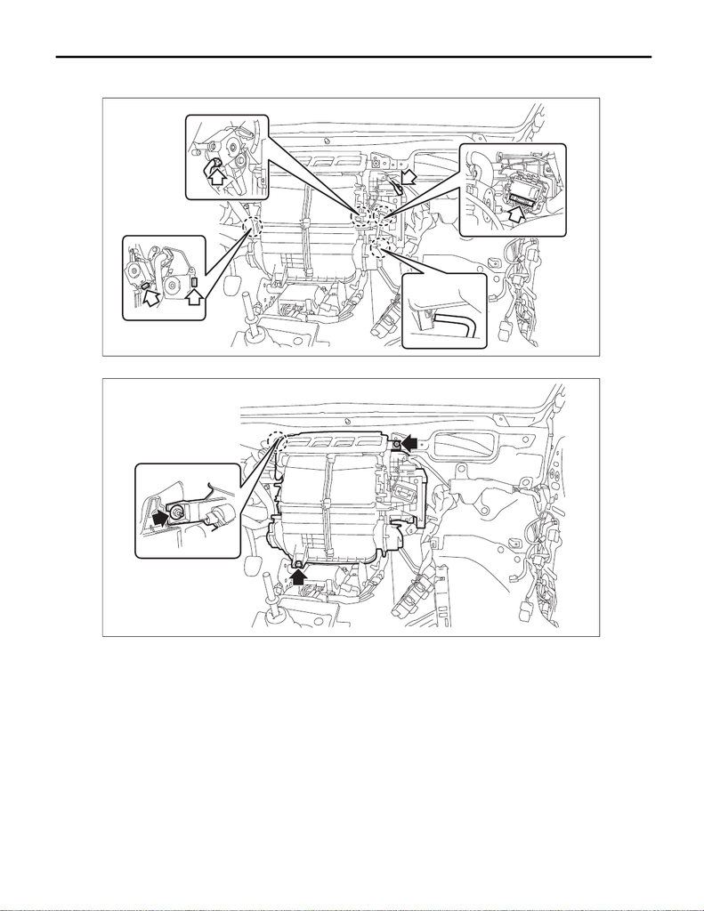

AC-55

Heater and Cooling Unit

HVAC SYSTEM (HEATER, VENTILATOR AND A/C)

10) Remove the heater and cooling unit assembly.

(1) Disconnect each connector and the hose - drain.

(2) Remove the bolt and nuts, and remove the heater & cooling unit assembly.

AC-03549

AC-02686

[figure not shown]

AC-56

Heater and Cooling Unit

HVAC SYSTEM (HEATER, VENTILATOR AND A/C)

B: INSTALLATION

CAUTION:

• Replace O-rings with new parts and install securely.

• Before handling the airbag module, refer to “CAUTION” of “General Description” in “AIRBAG SYS-

TEM”. <Ref. to AB-9, CAUTION, General Description.>

1) Install the heater and cooling unit assembly.

Tightening torque:

7.5 N·m (0.8 kgf-m, 5.5 ft-lb)

2) Install the blower motor unit assembly.

Tightening torque:

7.5 N·m (0.8 kgf-m, 5.5 ft-lb)

3) Install the engine control module (ECM). (STI model) <Ref. to FU(STI)-56, INSTALLATION, Engine Con-

trol Module (ECM).>

4) Install the instrument panel assembly. <Ref. to EI-77, INSTALLATION, Instrument Panel Assembly.>

5) Attach the heater hose.

6) Install the hose - pressure suction and the pipe - evaporator cooling.

Tightening torque:

7.5 N·m (0.8 kgf-m, 5.5 ft-lb)

7) Install the intercooler.

• Except for STI model: <Ref. to IN(w/o STI)-41, INSTALLATION, Intercooler.>

• STI model: <Ref. to IN(STI)-14, INSTALLATION, Intercooler.>

8) Connect the battery ground terminal. <Ref. to NT-5, BATTERY, NOTE, Note.>

NOTE:

For models other than STI model, connect the ground terminal to battery sensor.

9) Fill engine coolant.

• Except for STI model: <Ref. to CO(w/o STI)-14, FILLING OF ENGINE COOLANT, REPLACEMENT, En-

gine Coolant.>

• STI model: <Ref. to CO(STI)-13, FILLING OF ENGINE COOLANT, REPLACEMENT, Engine Coolant.>

10) Charge refrigerant. <Ref. to AC-27, PROCEDURE, Refrigerant Charging Procedure.>